# patreco-week-4

wildhtob

7 5 2021

# Exercises Week 4

## Libraries

```r
library(readr)
library(dplyr)
library(ggplot2)
library(lubridate)
library(sf)
```

## Functions

Trying out some dummy functions. Normally, all the functions would go here but the actual functions for this exercise are to be found in Task 1.

```r
# simple funtion to demonstrate its structure
testfun <- function() {print("this function does nothing")}
testfun()
```

```
## [1] "this function does nothing"
```

```r
# calculcating age based on birthday
my_age <- function(birthday, units = "days") {
  difftime(Sys.time(), birthday, units = units)
}

my_age("1980-01-01", "weeks")
```

```
## Time difference of 2159.53 weeks
```

## Data Import

```r
wildschwein <- read_delim("data/wildschwein_BE_2056.csv", ",")
```

## Task 1: Writing a function

Creating a function for the Euclidian distance calculation. Two seperate functions. One for lead and one for lag. The default interval is set to 1 but can be changed, as we did in exercise 3 to calculate different steplengths.

```r
euclid_dist <- function(e1, e2, n1, n2) {
  sqrt((e1 - e2)^2 + (n1 - n2)^2)
}

euclid_lead <- function (df, interval = 1) {
  sqrt((df$E - lead(df$E, interval))^2 +
       (df$N - lead(df$N, interval))^2)
}

euclid_lag <- function (df, interval = 1) {
  sqrt((lag(df$E, interval) - df$E)^2 +
       (lag(df$N, interval) - df$N)^2)
}
```

Testing the function with the wildboar data.

```r
wildschwein$steplength1 <- euclid_lead(wildschwein)
wildschwein$steplength2 <- euclid_lead(wildschwein, 2)
```

## Task 2: Preparing analysis

```r
str(wildschwein) #Datetime is already formated correctly
```

```
## spec_tbl_df[,6] [51,246 x 6] (S3: spec_tbl_df/tbl_df/tbl/data.frame)
##  $ TierID     : chr [1:51246] "002A" "002A" "002A" "002A" ...
##  $ TierName   : chr [1:51246] "Sabi" "Sabi" "Sabi" "Sabi" ...
##  $ CollarID   : num [1:51246] 12275 12275 12275 12275 12275 ...
##  $ DatetimeUTC: POSIXct[1:51246], format: "2014-08-22 21:00:12" "2014-08-22 21:15:16" ...
##  $ E          : num [1:51246] 2570409 2570402 2570394 2570379 2570390 ...
##  $ N          : num [1:51246] 1204752 1204863 1204826 1204817 1204818 ...
##  - attr(*, "spec")=
##   .. cols(
##   ..   TierID = col_character(),
##   ..   TierName = col_character(),
##   ..   CollarID = col_double(),
##   ..   DatetimeUTC = col_datetime(format = ""),
##   ..   E = col_double(),
##   ..   N = col_double()
##   .. )
```

```r
time_start <- as.POSIXct("2015-04-01", tz = "UTC") # UTC is the default timzone
time_end <- as.POSIXct("2015-04-16", TZ = "UTC")

wildschwein_subset <- wildschwein %>%
  filter(
    DatetimeUTC >= time_start & DatetimeUTC <= time_end,
    TierName == "Sabi" | TierName== "Rosa"
    )
```

## Taks 3: Create Join Key

Round the time stamps in order to compare Rosa and Sabis’ locations and to be able to apply a join. Round the minutes of `DatetimeUTC` to a multiple of 15 and put the values in a new column by using `round_date()`

```r
wildschwein_subset$time_rounded <- wildschwein_subset$DatetimeUTC %>%
  round_date("15 minutes")

head(wildschwein_subset)
```

```
## # A tibble: 6 x 7
##   TierID TierName CollarID DatetimeUTC              E      N time_rounded
##   <chr>  <chr>       <dbl> <dttm>               <dbl>  <dbl> <dttm>
## 1 002A   Sabi        12275 2015-04-01 00:00:11 2.57e6 1.21e6 2015-04-01 00:00:00
## 2 002A   Sabi        12275 2015-04-01 00:15:22 2.57e6 1.21e6 2015-04-01 00:15:00
## 3 002A   Sabi        12275 2015-04-01 00:30:11 2.57e6 1.21e6 2015-04-01 00:30:00
## 4 002A   Sabi        12275 2015-04-01 00:45:16 2.57e6 1.21e6 2015-04-01 00:45:00
## 5 002A   Sabi        12275 2015-04-01 01:00:44 2.57e6 1.21e6 2015-04-01 01:00:00
## 6 002A   Sabi        12275 2015-04-01 01:15:17 2.57e6 1.21e6 2015-04-01 01:15:00
```

## Task 4: Measuring distance at concurrent locations

Splitting the subset data into one df per animal.

```r
wildschwein_split <- wildschwein_subset %>%
  group_split(TierName) %>%
  setNames(c("Rosa", "Sabi")
  )

list2env(wildschwein_split, envir = .GlobalEnv)
```

```
## <environment: R_GlobalEnv>
```

Rejoining the dataframes by `time_rounded` using `inner_join` because only data points with temporal closeness are interesting here.

```r
wildschwein_join <- inner_join(
  Sabi, Rosa, by = "time_rounded", suffix = c("_sabi", "_rosa")
  )
```

Calculating the Euclidian distance using the definied function `euclid_dist`

```r
wildschwein_join <- wildschwein_join %>%
  mutate(
    distance = euclid_dist(.$E_sabi, .$E_rosa, .$N_sabi, .$N_rosa)
    )
```

Or manually:

```r
wildschwein_join <- wildschwein_join %>%
    mutate(
    distance = sqrt((E_sabi - E_rosa)^2 + (N_sabi - N_rosa)^2)
    )
```

Calculating spatial closeness using a distance threshold.

```r
wildschwein_join$meet <- ifelse(wildschwein_join$distance <= 100, TRUE, FALSE)
```

## Task 5: Visualise data

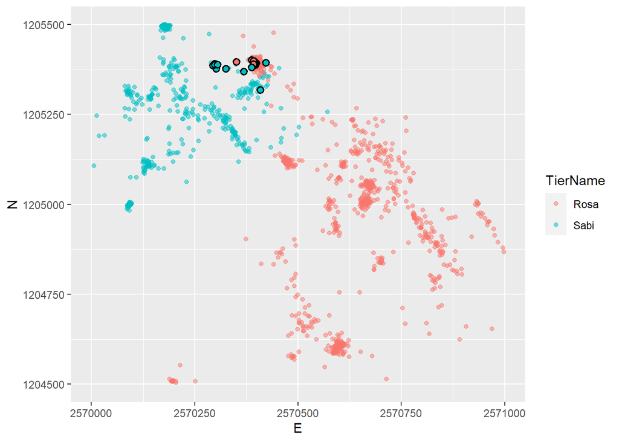

```r
ggplot(filter(wildschwein_join, meet == TRUE)) +
  geom_point(data = wildschwein_subset, aes(E, N, colour = TierName), alpha = 0.5) +
  geom_point(aes(E_rosa, N_rosa),
    shape = 21, colour = "black",
    fill = "#F8766D", stroke = 1, size = 2, alpha = 1
  ) +
  geom_point(aes(E_sabi, N_sabi),
    shape = 21, colour = "black",
    fill = "#00BFC4", stroke = 1, size = 2, alpha = 1
  ) +
  xlim(2570000, 2571000) +
  ylim(1204500, 1205500)
```

```r
# The legend is missing the meeting points. To be resolved.
```